# Homework to StatComp21062

Yimeng Sun

2021-12-19

## Generate texts, figures and tables

### 1.生成文字

统计计算是一门与R语言有关的课程，它开设于2021年秋季，授课老师是张洪教授

### 2.生成图形

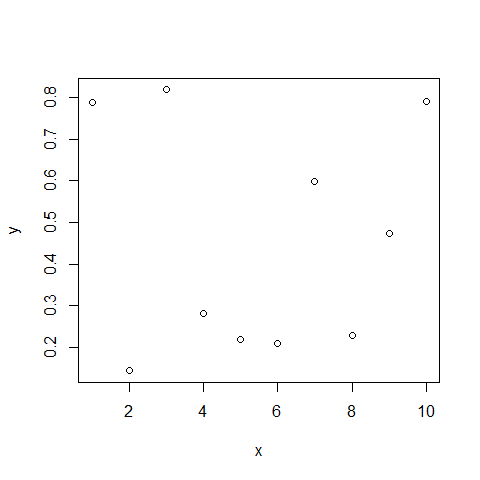

```r
x = 1:10
y = runif(10)
plot(x,y,type = "p")
```

### 3.生成表格

```r
x = 1:20; y = x^2;
lmr = lm(y ~ x)
Co = summary(lmr)$coefficients
print(Co)
```

[output not shown]

```r
knitr::kable(Co,align = 'c')
```

|  | Estimate | Std. Error | t value | Pr(>\|t\|) |
| --- | --- | --- | --- | --- |
| (Intercept) | -77 | 14.50747 | -5.307611 | 4.79e-05 |
| x | 21 | 1.21106 | 17.340179 | 0.00e+00 |

## Question

#### Exercises 3.4, 3.11, and 3.20

## Answer

### 3.4

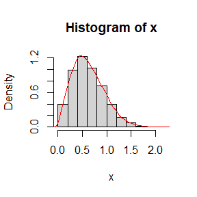

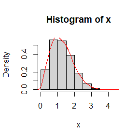

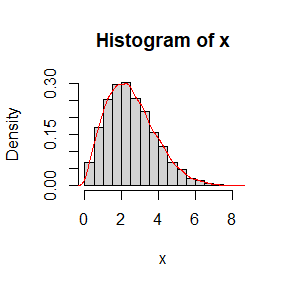

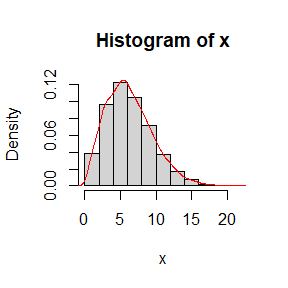

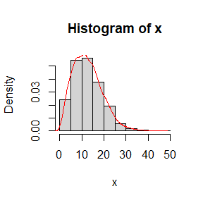

```r
for(i in c(0.5,1,2,5,10))
{
  sigma = i #参数sigma取不同的值
  N = 10000
  u = runif(N,min=0,max=1)
  x = sqrt(-2*sigma^2*log(1-u)) #模拟生成服从Rayleigh分布的随机变量
  hist(x,freq = F) #这里画出直方图，注意纵坐标显示的是频率，因为freq = F
  lines(density(x),col = "red") #这里画出密度函数，也可以观察出生成的随机变量是否具有Rayleigh分布的形式
}
```

### 3.11

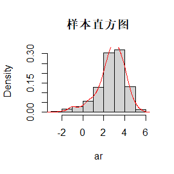

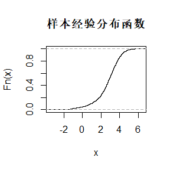

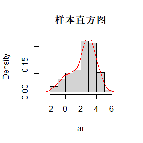

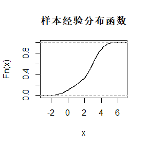

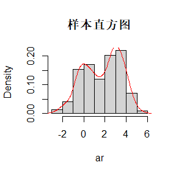

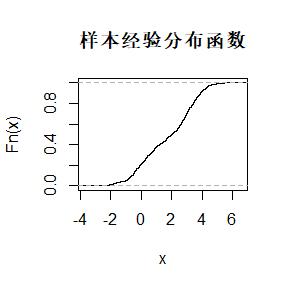

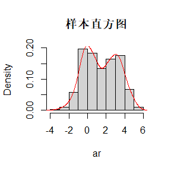

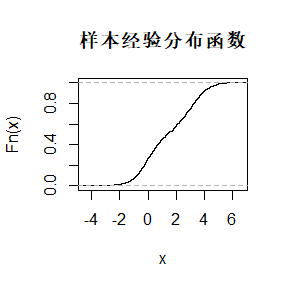

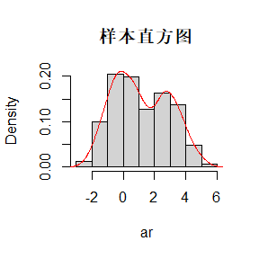

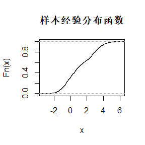

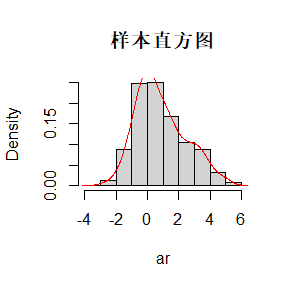

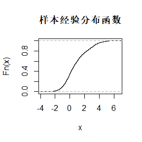

[4 more figures not shown]

```r
for(p in c(0.1,0.2,0.4,0.5,0.6,0.75,0.8,0.9)) #题目中给定的p1=0.75也放在循环里了
{
    ar = matrix(0,1,1000)
  for(i in 1:1000) #生成1000个服从N(0,1)和N(3,1)混合分布的随机变量
  {
    u = runif(1,min=0,max=1)
    if(u<p)
      x = rnorm(1,0,1) else
        x = rnorm(1,3,1)
    ar[i] = x
  }
  hist(ar,freq = F,main = "样本直方图") #画出样本直方图
  lines(density(ar),col = "red") #画出样本密度函数
  plot.ecdf(ar,main = "样本经验分布函数") #画出样本经验函数
}
```

#### 输出的十六张图片分别是p1=0.1,0.2,0.4,0.5,0.6,0.75,0.8,0.9时产生样本所对应的直方图（包含了密度函数）和经验函数，从密度函数可以看出样本的双峰特性还是很明显的，峰所对应的横坐标分别为0和3，也就是所混合的两个正态分布N(0,1)和N(3,1)的均值，当p1接近于0时，样本更容易从N(3,1)中产生，所以混合密度函数的峰主要出现在横坐标为3处，此时的另一个峰并不明显；同样，当p1接近于1时，样本更容易从N(0,1)中产生，所以混合密度函数的峰主要出现在横坐标为0处，此时的另一个峰也并不明显，只有当p1和p2的值比较接近时，双峰特性才比较明显。可以得出结论，如果p1的值比较接近0.5，双峰特性会比较明显，如果p1的值接近0或者1，则主要呈现出单峰特征（峰值出现在横坐标为3或者0处），由此可以猜测p1的大致范围。

### 3.20

首先明确N(10)是服从参数为lamda*t=60（取lamda=6，已知t=10）的泊松分布，Y1，Y2，...是服从alpha=1，beta=2的伽马分布（这只是其中一种情况，参数可以变化）

```r
lamda = 6
alpha = 1
beta = 2 #明确参数的取值
X = matrix(0,1,1000)
for(i in 1:1000) #重复1000次模拟
{
  N = rpois(1,10*lamda) #随机生成N(10)
  y = rgamma(N,shape = alpha,scale = 1/beta) #随机生成Y1,Y2,...,YN,均服从Gamma(1,2)
  X[i] = sum(y) #Y1,Y2,...,YN的和为X(10)的一个模拟值
}
mean = mean(X)
var = sd(X)^2
cat("估计的均值和方差分别为",mean,var)
```

```
## 估计的均值和方差分别为 29.93917 29.22914
```

```r
Mean = 10*lamda*alpha*(1/beta)
Var = 10*lamda*alpha*(alpha+1)*(1/beta^2)
cat("理论的均值和方差分别为",Mean,Var)
```

```
## 理论的均值和方差分别为 30 30
```

#### 更改lamda、alpha和beta的值可以进行多次运算，其均值和方差的估计值和理论值相差都不大，下面再给出一些例子

##### lamda=10,alpha=2,beta=1

```r
lamda = 10
alpha = 2
beta = 1
X = matrix(0,1,1000)
for(i in 1:1000)
{
  N = rpois(1,10*lamda)
  y = rgamma(N,shape = alpha,scale = 1/beta)
  X[i] = sum(y)
}
mean = mean(X)
var = sd(X)^2
cat("估计的均值和方差分别为",mean,var)
```

```
## 估计的均值和方差分别为 201.9475 584.5192
```

```r
Mean = 10*lamda*alpha*(1/beta)
Var = 10*lamda*alpha*(alpha+1)*(1/beta^2)
cat("理论的均值和方差分别为",Mean,Var)
```

```
## 理论的均值和方差分别为 200 600
```

##### lamda=1,alpha=3,beta=4

```r
lamda = 1
alpha = 3
beta = 4
X = matrix(0,1,1000)
for(i in 1:1000)
{
  N = rpois(1,10*lamda)
  y = rgamma(N,shape = alpha,scale = 1/beta)
  X[i] = sum(y)
}
mean = mean(X)
var = sd(X)^2
cat("估计的均值和方差分别为",mean,var)
```

```
## 估计的均值和方差分别为 7.476986 7.715522
```

```r
Mean = 10*lamda*alpha*(1/beta)
Var = 10*lamda*alpha*(alpha+1)*(1/beta^2)
cat("理论的均值和方差分别为",Mean,Var)
```

```
## 理论的均值和方差分别为 7.5 7.5
```

##### lamda=2,alpha=8,beta=10

```r
lamda = 2
alpha = 8
beta = 10
X = matrix(0,1,1000)
for(i in 1:1000)
{
  N = rpois(1,10*lamda)
  y = rgamma(N,shape = alpha,scale = 1/beta)
  X[i] = sum(y)
}
mean = mean(X)
var = sd(X)^2
cat("估计的均值和方差分别为",mean,var)
```

```
## 估计的均值和方差分别为 15.94612 14.58378
```

```r
Mean = 10*lamda*alpha*(1/beta)
Var = 10*lamda*alpha*(alpha+1)*(1/beta^2)
cat("理论的均值和方差分别为",Mean,Var)
```

```
## 理论的均值和方差分别为 16 14.4
```

## Question

### Exercises 5.4, 5.9, 5.13 and 5.14

## Answer

### 5.4

```r
MC_cdf = function(x,a,b) {
  u = runif(5000,min = 0,max = x)
  f = gamma(a+b)/(gamma(a)*gamma(b))*u^(a-1)*(1-u)^(b-1) #这是贝塔分布的密度函数，用上一步生成的u来计算f(u)
  cdf = x*mean(f) #估计F(x)
}

x = seq(0.1,0.9,0.1)
for (i in x)
{
  MC_estimate = MC_cdf(i,3,3) #估计Beta(3,3)的cdf
  pbeta_value = pbeta(i,3,3)
  print(c(i,MC_estimate,pbeta_value)) #分别输出x的值,Monte Carlo估计值和pbeta返回的值
}
```

```
## [1] 0.10000000 0.00852203 0.00856000
## [1] 0.20000000 0.05866129 0.05792000
## [1] 0.3000000 0.1654097 0.1630800
## [1] 0.4000000 0.3130108 0.3174400
## [1] 0.5000000 0.4969893 0.5000000
## [1] 0.6000000 0.6834847 0.6825600
## [1] 0.7000000 0.8376133 0.8369200
## [1] 0.8000000 0.9402855 0.9420800
## [1] 0.900000 1.002482 0.991440
```

#### 可以看出用Monte Carlo方法估计的Beta(3,3)的分布函数值与R中pbeta函数所返回的值非常接近

### 5.9

```r
# 设计一个函数，可以利用对偶变量生成服从Rayleigh分布的随机变量
Rayleigh_Sample = function(sigma){
  u = runif(1,min=0,max=1)
  x1 = sqrt(-2*sigma^2*log(1-u))
  x2 = sqrt(-2*sigma^2*log(u))
  return((x1+x2)/2)
}
Rayleigh_Sample(0.5) # 取不同的参数sigma，得到生成的随机变量
```

```
## [1] 0.5985526
```

```r
Rayleigh_Sample(1)
```

```
## [1] 1.179511
```

```r
Rayleigh_Sample(2)
```

```
## [1] 2.39946
```

```r
Rayleigh_Sample(5)
```

```
## [1] 7.634215
```

```r
# 计算使用不同方法（对偶变量、独立变量）下样本的方差及减少的比例
Rayleigh_Sample_Var = function(sigma,n,antithetic = TRUE){
  u = runif(n)
  if (antithetic){
    X1 = sqrt(-2*sigma^2*log(1-u))
    X2 = sqrt(-2*sigma^2*log(u))
    variance = (var(X1)+var(X2)+2*cov(X1,X2))/4 #计算(X1+X2)/2的样本方差，此时X1和X2负相关
  }
  else{
    v = runif(n)
    X1 = sqrt(-2*sigma^2*log(1-u))
    X2 = sqrt(-2*sigma^2*log(1-v))
    variance = (var(X1)+var(X2))/4 #计算(X1+X2)/2的样本方差，此时X1和X2独立
  }
variance
}

var1 = Rayleigh_Sample_Var(1,1000,antithetic = FALSE) #取参数sigma=1，样本量n=1000（都是任意的），计算样本方差
var2 = Rayleigh_Sample_Var(1,1000,antithetic = TRUE)
ratio = 100*(var1-var2)/var1 #计算方差减少的比例（百分比）
print(c(var1,var2,ratio)) #输出结果
```

```
## [1]  0.22133109  0.01044872 95.27914610
```

#### 函数Rayleigh_Sample可以利用对偶变量生成服从Rayleigh分布的随机变量，函数Rayleigh_Sample_Var可以返回不同方法下的样本方差，明显看到相对于利用独立变量，利用对偶变量可以大幅度地减少样本方差，是比较好的模拟方法

### 5.13

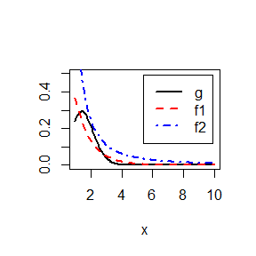

```r
x = seq(1,10,0.05)
g = (1/(sqrt(2*pi)))*x^2*exp(-x^2/2)
f1 = exp(-x)
f2 = 1/x^2 #挑选g(x)的两个importance function

# 在同一张图上画出g,f1,f2的密度函数
plot(x,g,type = "l",ylab = "",ylim = c(0,0.5),lwd = 2)
lines(x, f1, lty = 2, lwd = 2, col = "red")
lines(x, f2, lty = 4, lwd = 2, col = "blue")
legend("topright",legend = c("g","f1","f2"),lty = c(1,2,4),col = c("black","red","blue"),lwd = 2,inset = 0.05)
```

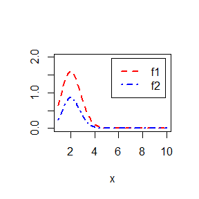

```r
# 在同一张图上画出g与f1,f2的比例
plot(x,g/f1,type = "l",ylab = "",ylim = c(0,2),lty = 2,lwd = 2,col = "red")
lines(x,g/f2,lty = 4,lwd = 2,col = "blue")
legend("topright",legend = c("f1","f2"),lty = c(2,4),col = c("red","blue"),lwd = 2,inset = 0.05)
```

```r
n = 5000
se = numeric(2)
g = function(x){
  (1/(sqrt(2*pi)))*x^2*exp(-x^2/2)*(x > 1)
}
# 用f1作为importance function
u = runif(n,0,1)
x = -log(1-u) #满足密度函数为f1
fg = g(x)/exp(-x)
se[1] = sd(fg)
# 用f2作为importance function
u = runif(n,0,1)
x = 1/(1-u) #满足密度函数为f2
fg = g(x)/(1/x^2)
se[2] = sd(fg)
print(round(se,4)) #输出估计量的标准差
```

```
## [1] 0.5860 0.3053
```

### 5.14

#### 从5.13的结果我们得到f2 = 1/x^2是一个相对较好的importance function，所以不妨就选择f2 = 1/x^2来进行Monte Carlo估计

```r
g = function(x){
  (1/(sqrt(2*pi)))*x^2*exp(-x^2/2)*(x > 1)
}
n = 10000
u = runif(n,0,1)
x = 1/(1-u) #X的密度函数为f2 = 1/x^2
fg = g(x)/(1/x^2)
MC_est = mean(fg)
MC_est
```

```
## [1] 0.405829
```

```r
Real_value = integrate(g,1,Inf)
Real_value
```

```
## 0.400626 with absolute error < 5.7e-07
```

#### 输出的MC_est就是利用importance sampling得到的积分的Monte Carlo估计，可以发现它与真实的积分值非常接近，所以具有很好的估计效果

## Question

### Exercises 6.5, 6.A and Discussion

## Answer

### 6.5

```r
# Use a Monte Carlo experiment to estimate the coverage probability of the t-interval
set.seed(111)
n = 20
alpha = 0.05
m = 1000 #重复次数
LCL = numeric(m)
UCL = numeric(m)
for(i in 1:m)
{
  x = rchisq(n, 2)
  LCL[i] = mean(x) + qt(alpha/2,df=n-1)*sd(x)/sqrt(n) #注意qt中的lower.tail默认为TRUE,意为P(X ≤ x),所以这里是+号,计算UCL时为-号
  UCL[i] = mean(x) - qt(alpha/2,df=n-1)*sd(x)/sqrt(n)
}
#计算coverage probability(CP)
sum = 0
for (i in 1:1000)
{
  if(LCL[i] <= 2 && UCL[i] >= 2) #表示χ2(2)的理论均值2落在CI内
    sum = sum + 1
}
CP = sum/1000
CP
```

```
## [1] 0.917
```

```r
# Example 6.4(Confidence interval for variance) 用例子中的方法估计方差的CP
UCL_var = numeric(m)
for(i in 1:m)
{
  y = rchisq(n, 2)
  UCL_var[i] = (n-1)*var(y)/qchisq(alpha,df = n-1)
}
sum_var = 0
for (i in 1:1000)
{
  if(UCL_var[i] > 4) #表示χ2(2)的理论方差4落在CI内
    sum_var =sum_var + 1
}
CP_var = sum_var/1000
CP_var
```

```
## [1] 0.773
```

#### 可以看出估计的均值的CP为0.917，不等于0.95，而是比0.95小一些；同时，通过Example 6.4中的方法计算出的方差的CP仅为0.773，和0.95相差较大，因此我们可以得到结论：The t-interval is more robust to departures from normality than the interval for variance.

### 6.A

```r
n = c(10,20,50,100,200)
L = length(n)
p1_hat = numeric(L)
p2_hat = numeric(L)
p3_hat = numeric(L)
alpha = 0.05
mu0 = 1
m = 10000
p1 = numeric(m)
p2 = numeric(m)
p3 = numeric(m)

# χ2(1)
for(i in 1:L)
{
  num = n[i]
  for(j in 1:m)
  {
    x = rchisq(num,1)
    ttest1 = t.test(x,mu = mu0)
    p1[j] = ttest1$p.value
  }
  p1_hat[i] = mean(p1 <= alpha)
}
cat("在抽样总体为χ2(1)时,当n分别为10,20,50,100,200,Type I error rate分别为",p1_hat,"\n")

# U(0,2)
for(i in 1:L)
{
  num = n[i]
  for(j in 1:m)
  {
    x = runif(num,0,2)
    ttest2 = t.test(x,mu = mu0)
    p2[j] = ttest2$p.value
  }
  p2_hat[i] = mean(p2 <= alpha)
}
cat("在抽样总体为U(0,2)时,当n分别为10,20,50,100,200,Type I error rate分别为",p2_hat,"\n")

# Exp(1)
for(i in 1:L)
{
  num = n[i]
  for(j in 1:m)
  {
    x = rexp(num,1)
    ttest3 = t.test(x,mu = mu0)
    p3[j] = ttest3$p.value
  }
  p3_hat[i] = mean(p3 <= alpha)
}
cat("在抽样总体为Exp(1)时,当n分别为10,20,50,100,200,Type I error rate分别为",p3_hat,"\n")
```

[output not shown]

#### 从上述结果可以看出，当样本量n逐渐增大时，Type I error rate是逐渐约等于名义显著性水平0.05的，从整体情况来看，抽样总体为U(0,2)时，Type I error rate的值比较稳定在0.05附近

### Discussion

```
## Question 1: What is the corresponding hypothesis test problem?
```

```
## Answer 1: The null hypothesis is the powers for two methods are same, while the alternative hypothesis is the powers for two methods are different.
```

```
## Question 2: What test should we use? Z-test, two-sample t-test, paired-t test or McNemar test? Why?
```

[output not shown]

```
## Question 3: Please provide the least necessary information for hypothesis testing.
```

[output not shown]

## Question

### Exercises 6.C

## Answer

### 6.C

```r
# Skewness test
# 不妨就使X和Y均从μ=(0,0,0)',∑=I(单位阵)的多元高斯分布N(μ,∑)中生成
library(MASS)
Mardia_test = function(data){
  n = nrow(data)
  d = ncol(data)
  central = matrix(0,n,d)
  for(i in 1:d){
    central[,i] = data[,i]-mean(data[,i])
  }
  sigma_hat = t(central)%*%central/n
  a = central%*%solve(sigma_hat)%*%t(central)
  b = sum(colSums(a^{3}))/(n*n)
  test = n*b/6
  chi = qchisq(0.95,d*(d+1)*(d+2)/6)
  as.integer(test > chi)
}

set.seed(123)
mu = c(0,0,0)
sigma = matrix(c(1,0,0,0,1,0,0,0,1),nrow = 3,ncol = 3)
m = 10000
n = c(10, 20, 30, 50, 100, 500)
p.reject = numeric(length(n))
for(i in 1:length(n)){
  p.reject[i] = mean(replicate(m, expr={
    data = mvrnorm(n[i],mu,sigma) #产生服从多元正态分布的随机数
    Mardia_test(data)
  }))
}
print(p.reject)
```

[output not shown]

#### 输出了Type I error rate的估计结果,可以看出当n逐渐增大(大于50)时,估计结果将接近名义水平α=0.05.

```r
# Power of the skewness test
# 不妨就取μ1=μ2=(0,0,0)',∑1=I(单位阵),∑2=diag(100,100,100)(对角阵),且contaminated multivariate normal distribution为(1−ε)N(μ1,∑1)+εN(μ2,∑2)
library(MASS)
set.seed(123)
mu1 = c(0,0,0)
mu2 = c(0,0,0)
sigma1 = matrix(c(1,0,0,0,1,0,0,0,1),nrow = 3,ncol = 3)
sigma2 = matrix(c(100,0,0,0,100,0,0,0,100),nrow = 3,ncol = 3)
sigma = list(sigma1,sigma2)
m = 2500
n = 30
epsilon = c(seq(0, 0.15, 0.01), seq(0.15, 1, 0.05))
N = length(epsilon)
pwr = numeric(N)
for (j in 1:N){
  e = epsilon[j]
  sktests = numeric(m)
  for (i in 1:m){
    index= sample(c(1, 2), replace = TRUE, size = n, prob = c(1-e, e))
    data = matrix(0,nrow = n,ncol = 3)
    for(t in 1:n){
      if(index[t] == 1) data[t,] = mvrnorm(1,mu1,sigma1) #从N(μ1,∑1)中生成
      else data[t,] = mvrnorm(1,mu2,sigma2) #从N(μ2,∑2)中生成
    }
    sktests[i] = Mardia_test(data) #利用上述Skewness test中的检验
  }
  pwr[j] = mean(sktests)
}
plot(epsilon, pwr, type = "b", xlab = bquote(epsilon), ylim = c(0,1))
abline(h = 0.1, lty = 3)
se = sqrt(pwr * (1-pwr) / m)
lines(epsilon, pwr+se, lty = 3)
lines(epsilon, pwr-se, lty = 3)
```

[output not shown]

#### 当ε=0或ε=1时,分布是多元正态的,而当0＜ε＜1时the empirical power of the test是大于0.05的并且大约在0.1＜ε＜0.3之间达到最大值(约为1)

## Question

### Exercises 7.7, 7.8, 7.9 and 7.B

## Answer

### 7.7

```r
library(boot)
library(bootstrap)
B = 1000
n = nrow(scor)
lambda_hat = eigen((n-1)/n*cov(scor))$values #极大似然估计
theta_hat = lambda_hat[1] / sum(lambda_hat)


set.seed(111)
func = function(data,i){
  x = data[i,]
  lambda = eigen((n-1)/n*cov(x))$values
  theta = lambda[1] / sum(lambda)
  return(theta)
}

bootstrap_result = boot(
  data = cbind(scor$mec,scor$vec,scor$alg,scor$ana,scor$sta),
  statistic = func,R = B)
theta_b = bootstrap_result$t

bias_boot = mean(theta_b)-theta_hat
se_boot = sqrt(var(theta_b))
# 输出结果
cat('The Bootstrap estimate of bias is :',bias_boot,'\n')
```

```
## The Bootstrap estimate of bias is : 0.0002975264
```

```r
cat('The Bootstrap estimate of standard error is :',se_boot,'\n')
```

```
## The Bootstrap estimate of standard error is : 0.04838029
```

### 7.8

```r
theta_j = rep(0,n)
for(i in 1:n)
{
  x = scor[-i,]
  lambda = eigen((n-2)/(n-1)*cov(x))$values
  theta_j[i] = lambda[1] / sum(lambda)
}
bias_jack = (n-1) * (mean(theta_j) - theta_hat)
se_jack = sqrt((n-1) * mean((theta_j - mean(theta_j))^2))
# 输出结果
cat('The Jackknife estimate of bias is :',bias_jack,'\n')
```

```
## The Jackknife estimate of bias is : 0.001069139
```

```r
cat('The Jackknife estimate of standard error is :',se_jack,'\n')
```

```
## The Jackknife estimate of standard error is : 0.04955231
```

### 7.9

```r
boot.ci(bootstrap_result, conf = 0.95, type = c('perc','bca'))
```

```
## BOOTSTRAP CONFIDENCE INTERVAL CALCULATIONS
## Based on 1000 bootstrap replicates
##
## CALL :
## boot.ci(boot.out = bootstrap_result, conf = 0.95, type = c("perc",
##     "bca"))
##
## Intervals :
## Level     Percentile            BCa
## 95%   ( 0.5159,  0.7079 )   ( 0.5113,  0.7048 )
## Calculations and Intervals on Original Scale
```

#### 从输出结果可以看出95% percentile CI为(0.5159,0.7079),95% BCa CI为(0.5113,0.7048)

### 7.B

```r
# estimate the standard normal bootstrap confidence interval, the basic bootstrap confidence interval, and the percentile confidence interval
n = 50 #样本量
m = 5000
B = 1000
set.seed(123)
CI_norm1 = matrix(0,m,2)
CI_basic1 = matrix(0,m,2)
CI_perc1 = matrix(0,m,2) #用来存放 normal population 的结果
CI_norm2 = matrix(0,m,2)
CI_basic2 = matrix(0,m,2)
CI_perc2 = matrix(0,m,2) #用来存放 χ2(5) distribution 的结果

skewness = function(data,i){
  x = data[i]
  xbar = mean(x)
  m3 = mean((x - xbar)^3)
  m2 = mean((x - xbar)^2)
  return(m3 / m2^1.5)
}

for(i in 1:m)
{
  x1 = rnorm(n)
  boot_result1 = boot(data = x1,statistic = skewness,R = B)
  boot_CI1 = boot.ci(boot_result1,type=c('norm','basic','perc'))
  CI_norm1[i,]<-boot_CI1$norm[2:3]
  CI_basic1[i,]<-boot_CI1$basic[4:5]
  CI_perc1[i,]<-boot_CI1$perc[4:5]
}
for(i in 1:m)
{
  x2 = rchisq(n,5)
  boot_result2 = boot(data = x2,statistic = skewness,R = B)
  boot_CI2 = boot.ci(boot_result2,type=c('norm','basic','perc'))
  CI_norm2[i,]<-boot_CI2$norm[2:3]
  CI_basic2[i,]<-boot_CI2$basic[4:5]
  CI_perc2[i,]<-boot_CI2$perc[4:5]
}
# use confidence interval to estimate the coverage probabilities
mu1 = 0 #N(0,1)的理论偏度为0
mu2 = sqrt(8/5) #χ2(5)的理论偏度为sqrt(8/5)
CP1_norm = mean(CI_norm1[,1]<=mu1 & CI_norm1[,2]>=mu1)
CP1_basic = mean(CI_basic1[,1]<=mu1 & CI_basic1[,2]>=mu1)
CP1_perc = mean(CI_perc1[,1]<=mu1 & CI_perc1[,2]>=mu1)
# 以上,计算三种CI下N(0,1)的CP
CP2_norm = mean(CI_norm2[,1]<=mu2 & CI_norm2[,2]>=mu2)
CP2_basic = mean(CI_basic2[,1]<=mu2 & CI_basic2[,2]>=mu2)
CP2_perc = mean(CI_perc2[,1]<=mu2 & CI_perc2[,2]>=mu2)
# 以上,计算三种CI下χ2(5)的CP
# 下面输出CP的结果
CP1 = cbind(CP1_norm,CP1_basic,CP1_perc)
CP2 = cbind(CP2_norm,CP2_basic,CP2_perc)
result = rbind(CP1,CP2)
colnames(result) = c("norm","basic","perc")
rownames(result) = c("N(0,1)","χ2(5)")
print(result)
```

[output not shown]

#### 以上,可以看到coverage rates for normal populations是比较接近0.95的,而coverage rates for χ2(5) distributions是比0.95小的,接近0.7

```r
# Find the proportion of times that the confidence intervals miss on the left, and the porportion of times that the confidence intervals miss on the right
left1 = cbind(mean(CI_norm1[,1]>mu1),mean(CI_basic1[,1]>mu1),mean(CI_perc1[,1]>mu1))
right1 = cbind(mean(CI_norm1[,2]<mu1),mean(CI_basic1[,2]<mu1),mean(CI_perc1[,2]<mu1))
# 以上,计算N(0,1)的miss on the left and right
left2 = cbind(mean(CI_norm2[,1]>mu2),mean(CI_basic2[,1]>mu2),mean(CI_perc2[,1]>mu2))
right2 = cbind(mean(CI_norm2[,2]<mu2),mean(CI_basic2[,2]<mu2),mean(CI_perc2[,2]<mu2))
# 以上,计算χ2(5)的miss on the left and right
# 下面输出miss的结果
miss = rbind(left1,right1,left2,right2)
colnames(miss) = c("norm","basic","perc")
rownames(miss) = c("left loss of N(0,1)","right loss of N(0,1)","left loss of χ2(5)","right loss of χ2(5)")
print(miss)
```

[output not shown]

#### 以上,可以看到N(0,1)的miss on the left and right是比较接近的,因为N(0,1)是对称的,而χ2(5)的miss是左边少于右边的,因为χ2(5)是右偏的

## Question

### Exercises 8.2 and experiments design

## Answer

### 8.2

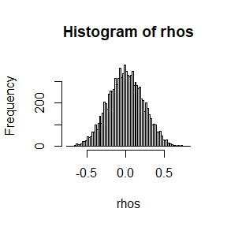

```r
set.seed(1)
x = rnorm(20,1,2)
y = rt(20,df=1) # Generate two groups of random numbers
#null hypothesis: true rho is equal to 0
cor.test = cor.test(x,y,method = "spearman")
rho = cor.test$estimate
p = cor.test$p.value

R = 10000
z = c(x, y)
K = length(z)
rhos = numeric(R)

for (i in 1:R) {
  k = sample(1:K,size = K/2,replace = FALSE)
  x1 = z[k]
  y1 = z[-k]
  rhos[i] = cor(x1,y1,method = "spearman")
}

hist(rhos,breaks = 100)
```

```r
p1 = mean(abs(rhos) > rho)
cat('The p-value reported by cor.test is:',p,'\n')
```

```
## The p-value reported by cor.test is: 0.5337769
```

```r
cat('The achieved significance level of the permutation test is:',p1,'\n')
```

```
## The achieved significance level of the permutation test is: 0.5243
```

#### We can see that the two p-values are very close. At the same time, if alpha = 0.05 is selected as the significant level, the p-value is obviously much greater than alpha. Therefore, we accept the null hypothesis that the two groups of numbers are independent, which is also in line with the reality

### experiments design

```r
library(RANN)
library(energy)
library(Ball)
library(boot)
set.seed(12345)
m = 50
k = 3
p = 2
n1 = 20
n2 = 20
N = c(n1,n2)
R = 1000

Tn = function(z,ix,sizes,k) {
  n1 = sizes[1]
  n2 = sizes[2]
  n = n1 + n2
  if(is.vector(z)) z = data.frame(z,0)
  z = z[ix, ]
  NN = nn2(data = z,k = k + 1)
  block1 = NN$nn.idx[1:n1,-1]
  block2 = NN$nn.idx[(n1+1):n,-1]
  i1 = sum(block1 < n1 + 0.5)
  i2 = sum(block2 > n1 + 0.5)
  return((i1 + i2) / (k * n))
}

eqdist.nn = function(z,sizes,k) {
  boot.obj = boot(data = z,statistic = Tn,R = R,sim = "permutation",sizes = sizes,k = k)
  ts = c(boot.obj$t0,boot.obj$t)
  p_value = mean(ts >= ts[1])
  list(statistic = ts[1],p.value = p_value)
}

p_values = matrix(NA,m,3)
```

$$F_1=N_2(\mu = (0, 0)_2, \Sigma = I_2), F_2 = N_2(\mu = (0, 0)_2, \Sigma = 2I_2)$$

```r
### Unequal variances and equal expectations
set.seed(12345)
for(i in 1:m){
  x = matrix(rnorm(n1*p,0,1),ncol = p)
  y = matrix(rnorm(n2*p,0,2),ncol = p)
  z = rbind(x,y)
  p_values[i,1] = eqdist.nn(z,N,k)$p.value #NN
  p_values[i,2] = eqdist.etest(z,sizes = N,R = R)$p.value #energy
  p_values[i,3] = bd.test(x = x,y = y,R = 1000,seed=i*12345)$p.value #Ball
}
alpha = 0.05
pow = colMeans(p_values < alpha)
data.frame(methods = c('NN','energy','Ball'),pow)
```

[output not shown]

#### The power of ball method is better than NN and energy methods

$$F_1=N_2(\mu = (0, 0)_2, \Sigma = I_2), F_2 = N_2(\mu = (1, 1)_2, \Sigma = 2I_2)$$

```r
### Unequal variances and unequal expectations
set.seed(12345)
for(i in 1:m){
  x = matrix(rnorm(n1*p,0,1),ncol = p)
  y = matrix(rnorm(n2*p,1,2),ncol = p)
  z = rbind(x,y)
  p_values[i,1] = eqdist.nn(z,N,k)$p.value #NN
  p_values[i,2] = eqdist.etest(z,sizes = N,R = R)$p.value #energy
  p_values[i,3] = bd.test(x = x,y = y,R = 1000,seed=i*12345)$p.value #Ball
}
alpha = 0.05
pow = colMeans(p_values < alpha)
data.frame(methods = c('NN','energy','Ball'),pow)
```

[output not shown]

#### The power of ball method is better than NN and energy methods

$$F_1=t_1, F_2 = N_1(1,1)*N_1(1,2)$$

```r
### Non-normal distributions: t distribution with 1 df (heavy-tailed distribution), bimodel distribution (mixture of two normal distributions)
set.seed(12345)
for(i in 1:m){
  x = matrix(rt(n1*p,df = 1),ncol = p)
  y1 = rnorm(n2*p,1,1)
  y2 = rnorm(n2*p,1,2)
  w = rbinom(n2*p,1,0.5)
  y = matrix(w*y1 + (1-w)*y2,ncol = p) #bimodel distribution
  z = rbind(x,y)
  p_values[i,1] = eqdist.nn(z,N,k)$p.value #NN
  p_values[i,2] = eqdist.etest(z,sizes = N,R = R)$p.value #energy
  p_values[i,3] = bd.test(x = x,y = y,R = 1000,seed=i*12345)$p.value #Ball
}
alpha = 0.05
pow = colMeans(p_values < alpha)
data.frame(methods = c('NN','energy','Ball'),pow)
```

[output not shown]

#### The power of energy method is better than NN and ball methods

$$F_1=t_1,F_2 = N_2((0,0),I_2)$$

```r
### Unbalanced samples
set.seed(12345)
n1 = 20
n2 = 50
N = c(n1,n2)
for(i in 1:m){
  x = matrix(rt(n1*p,df = 1),ncol = p)
  y = matrix(rnorm(n2*p,0,1),ncol = p)
  z = rbind(x,y)
  p_values[i,1] = eqdist.nn(z,N,k)$p.value #NN
  p_values[i,2] = eqdist.etest(z,sizes = N,R = R)$p.value #energy
  p_values[i,3] = bd.test(x = x,y = y,R = 1000,seed=i*12345)$p.value #Ball
}
alpha = 0.05
pow = colMeans(p_values < alpha)
data.frame(methods = c('NN','energy','Ball'),pow)
```

[output not shown]

#### The power of energy method is better than NN and ball methods

## Question

### Exercises 9.3 and 9.8 and Gelman-Rubin method

## Answer

### 9.3

```r
set.seed(123)
f = function(x,theta,eta) {
  return(1/(pi * theta * (1+((x-eta)/theta)^2)))
}

n = 10000
x = numeric(n)
u = runif(n)
theta = 1
eta = 0

x[1] = rnorm(1)
k = 0
for(i in 2:n) {
  xt = x[i-1]
  y = rnorm(1,mean=xt,sd=1.5) #choose normal distribution as proposal distribution
  num = f(y,theta,eta) * dnorm(xt,mean=y,sd=1.5)
  den = f(xt,theta,eta) * dnorm(y,mean=xt,sd=1.5)
  if(u[i] <= num/den) {
    x[i] = y
  }else {
    x[i] = xt #y is rejected
    k = k+1
  }
}

index = 1001:n
Estimated = quantile(x[index],seq(0,1,0.1))
Ture = qcauchy(seq(0,1,0.1))
data.frame(Estimated,Ture)
```

```
##         Estimated       Ture
## 0%   -11.33883716       -Inf
## 10%   -1.98264087 -3.0776835
## 20%   -1.06062237 -1.3763819
## 30%   -0.56553723 -0.7265425
## 40%   -0.22541541 -0.3249197
## 50%    0.07584349  0.0000000
## 60%    0.39407237  0.3249197
## 70%    0.76309125  0.7265425
## 80%    1.37537998  1.3763819
## 90%    2.91046515  3.0776835
## 100%  31.24559779        Inf
```

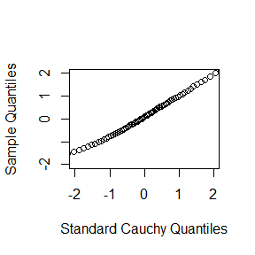

```r
a = ppoints(100)
Qc = qcauchy(a)
Q = quantile(x, a)
qqplot(Qc, Q, xlim = c(-2,2), ylim = c(-2,2), xlab = "Standard Cauchy Quantiles", ylab = "Sample Quantiles")
```

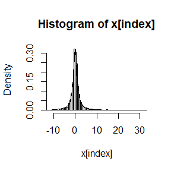

```r
hist(x[index], breaks = "scott", freq = FALSE)
lines(Qc, f(Qc, 1, 0))
```

#### Through the data and images, we can see that the estimated value of the quantile is very close to the true value.

### 9.8

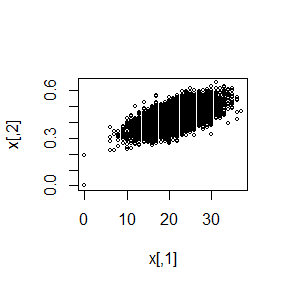

```r
n = 50
a = 30
b = 40
func = function(x, y) {
  gamma(n + 1) / (gamma(x + 1) * gamma(n - x + 1)) * y^(x + a - 1) * (1 - y)^(n - x + b - 1)
}
# generate the chain with target joint density f(x, y)
m = 10000
d = 2
x = matrix(0, nrow = m, ncol = d)
for (i in 2:m) {
  xt = x[i-1,] #initial (x,y)=(0,0)
  xt[1] = rbinom(1, n, xt[2])
  xt[2] = rbeta(1, xt[1] + a, n - xt[1] + b)
  x[i,] = xt
}
plot(x, cex = 0.5) #show the chain
```

### Gelman-Rubin method of monitoring convergence

```r
# For 9.3
Gelman.Rubin = function(psi) {
  psi = as.matrix(psi)
  n = ncol(psi)
  k = nrow(psi)
  psi.means = rowMeans(psi)
  B = n * var(psi.means)
  psi.w = apply(psi, 1, "var")
  W = mean(psi.w)
  v.hat = W * (n-1)/n + (B/n)
  r.hat = v.hat / W
  return(r.hat)
}

f = function(x,theta,eta) {
  return(1/(pi * theta * (1+((x-eta)/theta)^2)))
}
theta = 1
eta = 0

chain = function(n) {
  x = numeric(n)
  u = runif(n)
  x[1] = rnorm(1)
  k = 0
  for(i in 2:n) {
    xt = x[i-1]
    y = rnorm(1,mean=xt,sd=1.5) #choose normal distribution as proposal distribution
    num = f(y,theta,eta) * dnorm(xt,mean=y,sd=1.5)
    den = f(xt,theta,eta) * dnorm(y,mean=xt,sd=1.5)
    if(u[i] <= num/den) {
      x[i] = y
    }else {
      x[i] = xt #y is rejected
      k = k+1
    }
  }
  return(x)
}

k = 4
n = 10000
b = 1001

#generate the chains
set.seed(12)
X = matrix(0, nrow=k, ncol=n)
for (i in 1:k)
  X[i, ] = chain(n)

#compute diagnostic statistics
psi = t(apply(X, 1, cumsum))
for (i in 1:nrow(psi))
  psi[i,] = psi[i,] / (1:ncol(psi))
print(Gelman.Rubin(psi))

#plot psi for the four chains
par(mfrow=c(2,2))
for (i in 1:k)
  plot(psi[i, (b+1):n], type="l", xlab=i, ylab=bquote(psi))
par(mfrow=c(1,1)) #restore default

#plot the sequence of R-hat statistics
rhat = rep(0, n)
for (j in (b+1):n)
  rhat[j] = Gelman.Rubin(psi[,1:j])
plot(rhat[(b+1):n], type="l", xlab="",ylim = range(1,1.4), ylab="R")
abline(h=1.2, lty=2)
```

[output not shown]

#### We can see that when n is greater than 1000, the value of R will be less than 1.2, but there will be fluctuations, perhaps due to data or parameters.

```r
# For 9.8
Gelman.Rubin = function(psi) {
  psi = as.matrix(psi)
  n = ncol(psi)
  k = nrow(psi)
  psi.means = rowMeans(psi)
  B = n * var(psi.means)
  psi.w = apply(psi, 1, "var")
  W = mean(psi.w)
  v.hat = W * (n-1)/n + (B/n)
  r.hat = v.hat / W
  return(r.hat)
}

chain = function(m) {
  x = matrix(0, nrow = m, ncol = d)
  for (i in 2:m) {
    xt = x[i-1,] #initial (x,y)=(0,0)
    xt[1] = rbinom(1, n, xt[2])
    xt[2] = rbeta(1, xt[1] + a, n - xt[1] + b)
    x[i,] = xt
  }
  return(x)
}

k = 4
m = 10000
d = 2
n = 50
a = 30
b = 40
b1 = 1001

#For two-dimensional variables, we monitor the convergence of X and Y respectively
#generate the chains
set.seed(123)
X = matrix(0, nrow=k, ncol=m) #For X
Y = matrix(0, nrow=k, ncol=m) #For Y
for (i in 1:k){
  C = chain(m)
  X[i, ] = C[ ,1]
  Y[i, ] = C[ ,2]
}

#compute diagnostic statistics
psi = t(apply(X, 1, cumsum))
for (i in 1:nrow(psi))
  psi[i,] = psi[i,] / (1:ncol(psi))
print(Gelman.Rubin(psi)) #For X

phi = t(apply(Y, 1, cumsum))
for (i in 1:nrow(phi))
  phi[i,] = phi[i,] / (1:ncol(phi))
print(Gelman.Rubin(phi)) #For Y

#plot psi/phi for the four chains
par(mfrow=c(2,2))
for (i in 1:k)
  plot(psi[i, (b1+1):m], type="l", xlab=i, ylab=bquote(psi)) #For X
par(mfrow=c(1,1)) #restore default

par(mfrow=c(2,2))
for (i in 1:k)
  plot(phi[i, (b1+1):m], type="l", xlab=i, ylab=bquote(phi)) #For Y
par(mfrow=c(1,1)) #restore default

#plot the sequence of R-hat statistics
rhat = rep(0, m)
for (j in (b1+1):m)
  rhat[j] = Gelman.Rubin(psi[,1:j])
plot(rhat[(b1+1):m], type="l", xlab="",ylim = range(1,1.4), ylab="R")
abline(h=1.2, lty=2) #For X

rhat1 = rep(0, m)
for (j in (b1+1):m)
  rhat1[j] = Gelman.Rubin(phi[,1:j])
plot(rhat1[(b1+1):m], type="l", xlab="",ylim = range(1,1.4), ylab="R")
abline(h=1.2, lty=2) #For Y
```

[output not shown]

## Question

### Exercises 11.3 and 11.5 and E-M algorithm

## Answer

### 11.3

```r
a = c(1,2) #vector
d = length(a) #dimension

#compute the k-th term
Term = function(a,k) {
  d = length(a)
  return((-1)^k * exp((2*k + 2)*log(norm(a,type = "2")) - lgamma(k + 1) - k*log(2) - log(2*k + 1) - log(2*k + 2) + lgamma((d + 1)/2) + lgamma(k + 3/2) - lgamma(k + d/2 + 1)))
}

#compute the sum
n = 1000
Sum = function(a) {
  sum(sapply(0:n, function(k) Term(a,k)))
}

cat("The sum is",Sum(a))
```

```
## The sum is 1.532164
```

### 11.5

```r
solve.equation = function(k) {
  #the integrand
  integrand = function(u,n) {
    (1 + u^2/(n-1))^(-n/2)
  }
  #the upper limit ck
  c_k = function(a,n) {
    sqrt(a^2 * n / (n + 1 - a^2))
  }
  #the expression
  expr = function(a,n) {
    integral = function(u) {
      integrand(u,n)
    }
    c = c_k(a,n-1)
    2/sqrt(pi*(n-1)) * exp(lgamma(n/2)-lgamma((n-1)/2)) * integrate(integral, lower = 0, upper = c)$value
  }
  #express the equation
  f = function(a) {
    left = expr(a,k)
    right = expr(a,k + 1)
    return(left - right)
  }
  #solve the equation
  r = uniroot(f, lower=1, upper=2)$root
  return(r)
}

result = sapply(c(4:25, 100, 500, 1000), function(k) {solve.equation(k)})
result
```

```
##  [1] 1.492103 1.533556 1.562744 1.584430 1.601185 1.614521 1.625390 1.634419
##  [9] 1.642038 1.648554 1.654190 1.659114 1.663452 1.667303 1.670745 1.673840
## [17] 1.676637 1.679178 1.681496 1.683620 1.685572 1.687373 1.720608 1.729755
## [25] 1.730907
```

#### The results are basically consistent with those in Exercises 11.4.

### E-M algorithm

We consider the exponential distribution with the parameter $\lambda$. The i.i.d samples are $X_i,i=1,...,n$, and the observed values are $Y_i,i=1,...,n$. When $X_i < \tau$, $Y_i = X_i$, when $X_i > \tau$, $Y_i = \tau$. We know the log-likelihood for the exponential data is
$$L(\lambda;X_i)=n\ln(\lambda)-\lambda\sum_{i=1}^nX_i$$
Now we take the expected value of this formula under the current parameter $\lambda_i$ and conditional on our observations $y_i$ of the $Y_i$. So we get this:
$$E(L(\lambda;X_i)|Y_i=y_i,\lambda_i)=n\ln(\lambda)-\lambda\sum_{i=1}^nE(X_i|Y_i=y_i,\lambda_i)$$
When maximizing this result, we will get the new value of the parameter:
$$\lambda_{i+1}=\frac{n}{\sum_{i=1}^nE(X_i|Y_i=y_i,\lambda_i)}$$
Now let's consider the specific problem, $\tau = 1$, so if$X_i < 1,Y_i = X_i$, if$X_i > 1,Y_i = 1$.

The E-step:(Remember $Y_i = 1$ means $X_i > 1$, change the lower integral limit and adjust the coefficient)

$$E(X_i|Y_i=X_i,\lambda_i)=x_i$$
$$E(X_i|Y_i=1,\lambda_i)=e^{\lambda_i}\int_{1}^\infty x_i\lambda_ie^{-\lambda_ix_i}dx_i=1+\frac{1}{\lambda_i}$$
So in this problem, whe have:
$$\begin{aligned}
\sum_{i=1}^nE(X_i|Y_i=y_i,\lambda_i)&=0.54+0.48+0.33+0.43+0.91+0.21+0.85+3(1+\frac{1}{\lambda_i})\\&=3.75+3(1+\frac{1}{\lambda_i})
\end{aligned}$$
The M-step:(According to the previous analysis and $n=10$)

$$\lambda_{i+1}=\frac{10}{3.75+3(1+\frac{1}{\lambda_i})}$$
Do the E-step and M-step over again for using the starting parameter $\lambda_{i+1}$ rather than $\lambda_i$ until convergence.

##### Finally, we get the estimated expectation, that is, the reciprocal of the parameter $\lambda$, i.e. $\frac{1}{\lambda}$

```r
m = 10 #number of iterations
n = 10
lambda = numeric(m)
lambda[1] = 2 #initialization

for (i in 2:m) {
  E = 0.54 + 0.48 + 0.33 + 0.43 + 0.91 + 0.21 + 0.85 + 3 * (1 + 1/lambda[i-1])
  lambda[i] = n/E
}

print(1/lambda) #get the estimated expectation
```

```
##  [1] 0.5000000 0.8250000 0.9225000 0.9517500 0.9605250 0.9631575 0.9639473
##  [8] 0.9641842 0.9642553 0.9642766
```

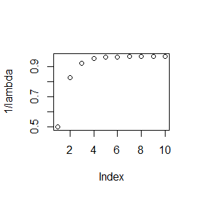

```r
plot(1/lambda)
```

## Question

### Page 204 Exercises 1 and 5; Page 214 Excecises 1 and 7

## Answer

### Page 204 Exercises 1

```r
trims <- c(0, 0.1, 0.2, 0.5)
x <- rcauchy(100)

lapply(trims, function(trim) mean(x, trim = trim))
```

```
## [[1]]
## [1] 34.23444
##
## [[2]]
## [1] -0.1460035
##
## [[3]]
## [1] -0.1154727
##
## [[4]]
## [1] -0.05117982
```

```r
lapply(trims, mean, x = x)
```

```
## [[1]]
## [1] 34.23444
##
## [[2]]
## [1] -0.1460035
##
## [[3]]
## [1] -0.1154727
##
## [[4]]
## [1] -0.05117982
```

#### 第一种方式是将trims的每个元素都逐一传入到定义的function(trim)中,也就是传入到mean(,)的第二个参数中;第二种方式是先把trims看成一个另外的参数,利用x = x把mean(,)中的一个参数x先设置好,再用trims的每个元素作为mean(,)中的trim取值;所以两种方式是等效的

### Page 204 Exercises 5

```r
# For Exercise 3
formulas <- list(
        mpg ~ disp,
        mpg ~ I(1/disp),
        mpg ~ disp + wt,
        mpg ~ I(1/disp) + wt
)
# For loops
lo <- list(NULL,NULL,NULL,NULL)
for (i in 1:4) {
  lo[[i]] <- lm(formulas[[i]], data = mtcars)
}
lo
```

```
## [[1]]
##
## Call:
## lm(formula = formulas[[i]], data = mtcars)
##
## Coefficients:
## (Intercept)         disp
##    29.59985     -0.04122
##
##
## [[2]]
##
## Call:
## lm(formula = formulas[[i]], data = mtcars)
##
## Coefficients:
## (Intercept)    I(1/disp)
##       10.75      1557.67
##
##
## [[3]]
##
## Call:
## lm(formula = formulas[[i]], data = mtcars)
##
## Coefficients:
## (Intercept)         disp           wt
##    34.96055     -0.01772     -3.35083
##
##
## [[4]]
##
## Call:
## lm(formula = formulas[[i]], data = mtcars)
##
## Coefficients:
## (Intercept)    I(1/disp)           wt
##      19.024     1142.560       -1.798
```

```r
# For lapply()
la <- lapply(formulas, lm, data = mtcars)
la
```

```
## [[1]]
##
## Call:
## FUN(formula = X[[i]], data = ..1)
##
## Coefficients:
## (Intercept)         disp
##    29.59985     -0.04122
##
##
## [[2]]
##
## Call:
## FUN(formula = X[[i]], data = ..1)
##
## Coefficients:
## (Intercept)    I(1/disp)
##       10.75      1557.67
##
##
## [[3]]
##
## Call:
## FUN(formula = X[[i]], data = ..1)
##
## Coefficients:
## (Intercept)         disp           wt
##    34.96055     -0.01772     -3.35083
##
##
## [[4]]
##
## Call:
## FUN(formula = X[[i]], data = ..1)
##
## Coefficients:
## (Intercept)    I(1/disp)           wt
##      19.024     1142.560       -1.798
```

```r
# extract R^2
rsq <- function(mod) summary(mod)$r.squared
result <- sapply(la, rsq)
cat("提取结果为：",result)
```

```
## 提取结果为： 0.7183433 0.8596865 0.7809306 0.8838038
```

```r
# For Exercise 5
bootstraps <- lapply(1:10, function(i) {
  rows <- sample(1:nrow(mtcars), rep = TRUE)
  mtcars[rows, ]
})
# For loops
lo2 <- list(NULL,NULL,NULL,NULL,NULL,NULL,NULL,NULL,NULL,NULL)
for (i in 1:10) {
  lo2[[i]] <- lm(mpg ~ disp, data = bootstraps[[i]])
}
lo2
```

```
## [[1]]
##
## Call:
## lm(formula = mpg ~ disp, data = bootstraps[[i]])
##
## Coefficients:
## (Intercept)         disp
##    28.53016     -0.03827
##
##
## [[2]]
##
## Call:
## lm(formula = mpg ~ disp, data = bootstraps[[i]])
##
## Coefficients:
## (Intercept)         disp
##    29.59946     -0.04159
##
##
## [[3]]
##
## Call:
## lm(formula = mpg ~ disp, data = bootstraps[[i]])
##
## Coefficients:
## (Intercept)         disp
##    27.88429     -0.03331
##
##
## [[4]]
##
## Call:
## lm(formula = mpg ~ disp, data = bootstraps[[i]])
##
## Coefficients:
## (Intercept)         disp
##    29.87487     -0.04156
##
##
```

[output cut: 43 more lines]

```
## lm(formula = mpg ~ disp, data = bootstraps[[i]])
##
## Coefficients:
## (Intercept)         disp
##    30.42834     -0.04262
##
##
## [[10]]
##
## Call:
## lm(formula = mpg ~ disp, data = bootstraps[[i]])
##
## Coefficients:
## (Intercept)         disp
##    27.18529     -0.03135
```

```r
# For lapply() without an anonymous function
la2 <- lapply(bootstraps, lm, formula = mpg ~ disp)
la2
```

```
## [[1]]
##
## Call:
## FUN(formula = ..1, data = X[[i]])
##
## Coefficients:
## (Intercept)         disp
##    28.53016     -0.03827
##
##
## [[2]]
##
## Call:
## FUN(formula = ..1, data = X[[i]])
##
## Coefficients:
## (Intercept)         disp
##    29.59946     -0.04159
##
##
## [[3]]
##
## Call:
## FUN(formula = ..1, data = X[[i]])
##
## Coefficients:
## (Intercept)         disp
##    27.88429     -0.03331
##
##
## [[4]]
##
## Call:
## FUN(formula = ..1, data = X[[i]])
##
## Coefficients:
## (Intercept)         disp
##    29.87487     -0.04156
##
##
```

[output cut: 43 more lines]

```
## FUN(formula = ..1, data = X[[i]])
##
## Coefficients:
## (Intercept)         disp
##    30.42834     -0.04262
##
##
## [[10]]
##
## Call:
## FUN(formula = ..1, data = X[[i]])
##
## Coefficients:
## (Intercept)         disp
##    27.18529     -0.03135
```

```r
# extract R^2
rsq <- function(mod) summary(mod)$r.squared
result2 <- sapply(la2, rsq)
cat("提取结果为：",result2)
```

```
## 提取结果为： 0.6794516 0.7069844 0.6251274 0.6674404 0.7440439 0.6711318 0.7704249 0.6413003 0.7452778 0.530934
```

### Page 214 Exercises 1

```r
library(bootstrap)
# (a) a numeric data frame "scor"
result <- vapply(scor, sd, numeric(1))
result
```

```
##      mec      vec      alg      ana      sta
## 17.48622 13.14695 10.62478 14.84521 17.25559
```

```r
cat("各列标准差为：",result,"\n")
```

```
## 各列标准差为： 17.48622 13.14695 10.62478 14.84521 17.25559
```

```r
# (b) a mixed data frame "iris"
result2 <- vapply(iris[vapply(iris, is.numeric, logical(1))], sd, numeric(1))
result2
```

```
## Sepal.Length  Sepal.Width Petal.Length  Petal.Width
##    0.8280661    0.4358663    1.7652982    0.7622377
```

```r
cat("各列标准差为：",result2)
```

```
## 各列标准差为： 0.8280661 0.4358663 1.765298 0.7622377
```

### Page 214 Exercises 7

```r
# sapply与lapply在功能实现上其实是一致的,只是输出结果略有不同,所以利用mclapply去实现mcsapply
mcsapply <- function(X, FUN, ..., simplify = TRUE, USE.NAMES = TRUE) {
  FUN <- match.fun(FUN)
  answer <- parallel::mclapply(X = X, FUN = FUN, ...)
  if (USE.NAMES && is.character(X) && is.null(names(answer)))
      names(answer) <- X
  if (!identical(simplify, FALSE) && length(answer))
      simplify2array(answer, higher = (simplify == "array"))
  else answer
}
```

#### vapply不能和sapply一样与lapply匹配(可能是因为参数"FUN.VALUE"),所以无法实现mcvapply()

## Question & Answer

### Write an Rcpp function for Exercise 9.8

```r
m = 10000
d = 2
# for R
GibbsR = function(n, a, b){
  x = matrix(0, nrow = m, ncol = d)
  for (i in 2:m) {
    xt = x[i-1,]
    xt[1] = rbinom(1, n, xt[2])
    xt[2] = rbeta(1, xt[1] + a, n - xt[1] + b)
    x[i,] = xt
  }
  return(x)
}

# for Rcpp
library(Rcpp)
cppFunction('NumericMatrix GibbsC(int n, int a, int b) {
NumericMatrix x(10000,2);
x(0,0) = 0;
x(0,1) = 0;
for (int i = 1; i < 10000; i++) {
int xt = rbinom(1, n, x(i-1,1))[0];
double yt = rbeta(1, xt + a, n - xt + b)[0];
x(i,0) = xt;
x(i,1) = yt;
};
return x;
}')
```

### Compare the corresponding generated random numbers with pure R language using the function "qqplot"

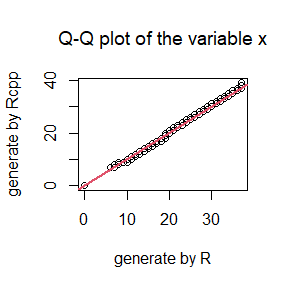

```r
n = 50
a = 30
b = 40
sampleR = GibbsR(n, a, b)
sampleC = GibbsC(n, a, b)
# the variable x of the chain
qqplot(sampleR[,1], sampleC[,1], xlab = "generate by R", ylab = "generate by Rcpp", main = expression("Q-Q plot of the variable x"))
abline(a = 0, b = 1, col = 2, lwd = 2)
```

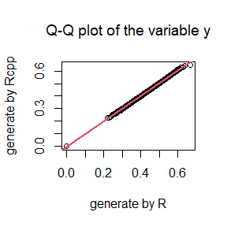

```r
# the variable y of the chain
qqplot(sampleR[,2], sampleC[,2], xlab = "generate by R", ylab = "generate by Rcpp", main = expression("Q-Q plot of the variable y"))
abline(a = 0, b = 1, col = 2, lwd = 2)
```